# Linear models

ECO 395M  
James Scott (UT-Austin)

Reference: Introduction to Statistical Learning Chapter 3

### Linear models

Linear modeling is the most widely used tool in the world for fitting a predictive model of the form \( y = f(x) + e \).

They are used throughout the worlds of science and industry.

They have been at the heart of some of history's greatest scientific discoveries.

### Linear models

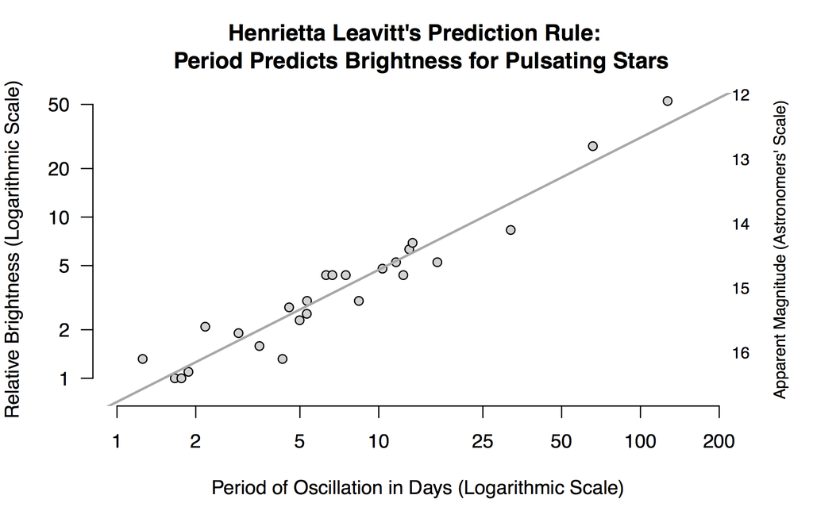

From *AIQ: How People and Machines are Smarter Together*

### Linear models

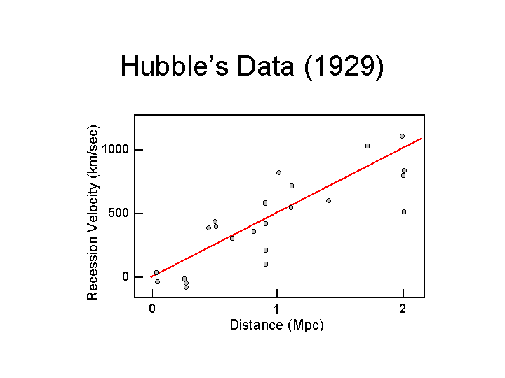

### Linear models

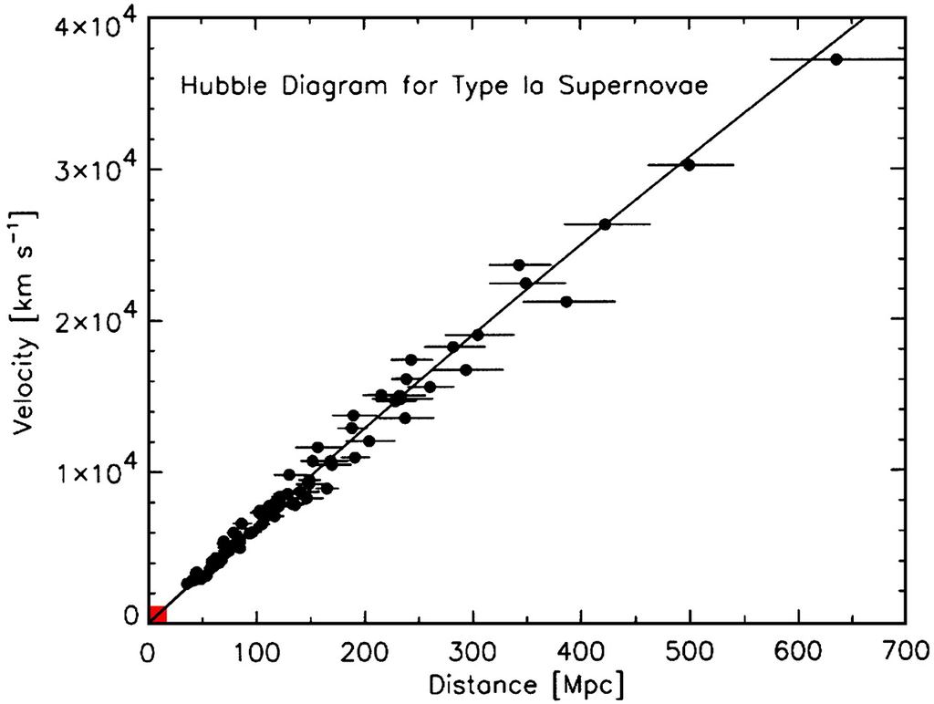

### Linear models

A linear model is parametric model; we can can write down \( f(x) \) in the form of an equation:

\[ \begin{aligned} y & = \beta_0 + \beta_1 x_1 + \cdots + \beta_p x_p + e \\ & = x \cdot \beta + e \end{aligned} \]

A notational convenience: the intercept gets absorbed into the vector of predictors by including a leading term of 1:

- \( x = (1, x_1, x_2, \dots, x_p) \)
- \( \beta = (\beta_0, \beta_1, \beta_2, \ldots, \beta_p) \)

### Linear models: major pros

- They often work pretty well for prediction.
- They're a simple foundation for more sophisticated techniques.
- They're easy to estimate, even for extremely large data sets.

### Linear models: major pros

- They have lower estimation variance than most nonlinear/nonparametric alternatives.
- They're easier to interpret than nonparametric models.
- Techniques for feature selection (choosing which \( x_j \)'s matter) are very well developed for linear models.

### Linear models: major cons

- Linear models are pretty much always wrong, sometimes subtly and sometimes spectacularly. If the truth is nonlinear, then the linear model will provide a biased estimate.
- Linear models depend on which *transformation* of the data you use (e.g. \( x \) versus \( \log(x) \)).
- Linear models don't handle *interactions* among the predictors unless you explicitly build them in.
- Linear models sometimes require extensive *feature engineering* in order to yield good performance.

### Interactions

We use the term **interaction** in statistical learning to describe situations where the effect of some feature \( x \) on the outcome \( y \) is **context-specific.**:

- Biking in a low gear: easy (say 2 out of 10)
- Biking in a high gear: a bit hard (say 4 out of 10)
- Biking uphill in a low gear: a bit hard (say 5 out of 10)
- Biking uphill in a high gear: *very* hard (say 9 out of 10)

### Huh? What's an interaction?

So what's the “effect” of change the gear from low to high? There is no one answer… **it depends on context!**

- On flat ground: “high gear” effect = 4 - 2 = 2.
- Uphill: “high gear” effect = 9 - 5 = 4.

One feature (slope) changes how another feature (gear) affects y.

**That's an interaction.**

### Other simple examples

What's the effect of a 5 mph breeze on comfort? It depends!

- When it's hot outside, a 5 mph breeze makes things more pleasant.
- What about the effect of the same breeze when it's cold outside?

What's the effect of two Tylenol pills on a headache? It depends!

- This dose will help a headache in a 165 pound adult human being.
- What about the effect of that same dose on a 13,000 pound African elephant?

### Linear models and interactions

Interactions are about capturing these context-specific effects by correctly modeling the *joint effect* of more than one feature at once.

The real world is full of interactions!

- house price versus (square footage, distance to downtown)
- college GPA versus (SAT Math score, college major)
- health outcomes vs (ACE inhibitors, pregnancy)

Linear models *can* accommodate interactions among feature variables—**but only** if we build these interaction terms in “by hand.”

### Example: orange juice sales

We'll see an example that illustrates the importance of transformations and hand-built interactions to get a good linear model.

- Three brands of OJ: Tropicana, Minute Maid, Dominicks
- 83 Chicago-area stores and demographic info for each store
- Price, sales (log units moved), and whether advertised (`feat`)
- data in `oj.csv`, code in `oj.R`.

### Example: orange juice sales

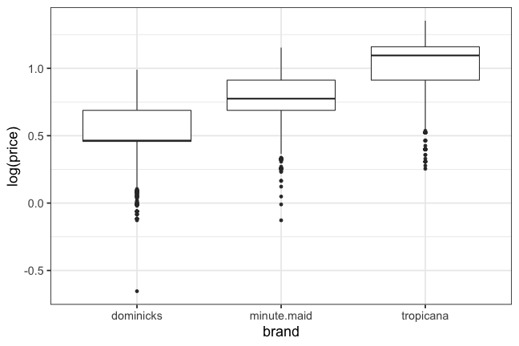

Each brand occupies a well-defined price range.

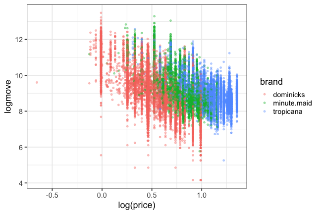

Sales decrease with price (duh).

### OJ example: teaching points

- Log-linear models: thinking about *scale* and the appropriate *transformation* in linear models.
- Interactions: must be hand-built, i.e. aren't automatically discovered by the fitting algorithm.

### Log-linear models

- When fitting a linear model (*this* goes up, *that* goes down), it's crucial that you think about the *scale* on which you expect to find linearity.
- A very common scale is to model the mean for \( \log(y) \) rather than \( y \). Remember, this allows us to model *multiplicative* rather than *additive* change.

\[ log(y) = \log(\beta_0) + \beta_1 x \iff y = \beta_0 e^{\beta_1 x} \]

- Change \( x \) by one unit \( \longrightarrow \) multiply \( E(y \mid x) \) by \( e^{\beta_1} \) units.

### Log-linear models

Whenever \( y \) changes on a percentage scale, use \( \log(y) \) as a response:

- prices: “Foreclosed homes sell at a 20\% discount…”
- sales: “Our Super Bowl ad improved y.o.y. sales by 7% on average, across all product categories.”
- volatility, failures, weather events… lots of things that are non-negative are expressed most naturally on a log scale.

### OJ: price elasticity

A simple “elasticity model” for orange juice sales \( y \) might be:

\[ \log(y) = \gamma \log(\mathrm{price}) + x \cdot \beta \]

The rough interpretation of a log-log regression like this: for every 1% increase in price, we can expect a \( \gamma \% \) change in sales.

Let's try this in R, using `brand` as a feature (\( x \)):

```r
reg = lm(logmove ~ log(price) + brand, data=oj)
coef(reg) ## look at coefficients
```

```
     (Intercept)       log(price) brandminute.maid   brandtropicana
      10.8288216       -3.1386914        0.8701747        1.5299428
```

### OJ: model matrix and dummy variables

What happened to `branddominicks`?

Our regression formulas look like \( \beta_0 + \beta_1 x_1 + \ldots \) But brand is not a number, so you can’t do \( \beta \cdot \mathrm{brand} \).

The first step of `lm` is to create a numeric “model matrix” from the input variables:

### OJ: model matrix and dummy variables

Input:

| Brand |
| --- |
| dominicks |
| minute maid |
| tropicana |

Variable expressed as a factor.

Output:

| Intercept | brand=minute maid | brand = tropicana |
| --- | --- | --- |
| 1 | 0 | 0 |
| 1 | 1 | 0 |
| 1 | 0 | 1 |

Variable coded as a set of numeric “dummy variables” that we can multiply against \( \beta \) coefficients. This is done using `model.matrix`. It's our first example of “feature engineering” (more later).

### OJ: model matrix and dummy variables

Our OJ model used `model.matrix` to build a 4 column matrix:

```
> x = model.matrix( ∼ log(price) + brand, data=oj)
> x[1,]
Intercept log(price) brandminute.maid brandtropicana
  1.00000   1.353255         0.000000       1.000000
```

Each factor’s reference level is absorbed by the intercept. Coefficients are “change relative to reference level” (dominicks here).

### Interactions

Remember: an interaction is when one feature changes how another feature acts on y.

In regression, an interaction is expressed as the product of two features:  
\[ E(y \mid x) = f(x) = \beta_0 + \beta_1 x_2 + \beta_2 x_2 + \beta_{12} x_1 x_2 + \cdots \] so that the effect on \( y \) of a one-unit increase in \( x_1 \) is \( \beta_1 + \beta_{12} x_2 \). (It depends on \( x_2 \)!)

### Interactions

Interactions play a *massive* role in statistical learning. They are important for making good predictions, and they are often central to social science and business questions:

- Does gender change the effect of education on wages?
- Do patients recover faster when taking drug A?
- How does brand affect price sensitivity?

### Interactions in R: use *

This model statement says: elasticity (the `log(price)` coefficient) is different from one brand to the next:

```r
reg3 = lm(logmove ~ log(price)*brand, data=oj)
coef(reg3)
```

```
                (Intercept)                  log(price)
                10.95468173                 -3.37752963
           brandminute.maid              brandtropicana
                 0.88825363                  0.96238960
log(price):brandminute.maid   log(price):brandtropicana
                 0.05679476                  0.66576088
```

This output is telling us that the elasticities are:

\( \quad \) dominicks: -3.4 \( \quad \) minute maid: -3.3 \( \quad \) tropicana: -2.7

Where do these numbers come from? Do they make sense?

### Interactions: OJ

- A key question: what changes when we feature a brand? Here, this means in-store display promo or flier ad (`feat` in `oj.csv`):
  1. You could model the additive effect of `feat` on log sales volume…
  2. Or (1) *and* an overall effect of `feat` on price elasticity…
  3. Or you could model a *brand-specific* effect of `feat` on elasticity.
- Let's see the R code in `oj.R` for runs of all three models.
- Goal: connect the regression formula and output to a specific equation, i.e. \( f(x) = E(y \mid x) \) for each brand individually.

### Brand-specific elasticities

|  | Dominicks | Minute Maid | Tropicana |
| --- | --- | --- | --- |
| Not featured | -2.8 | -2.0 | -2.0 |
| Featured | -3.2 | -3.6 | -3.5 |

Findings:

- Ads always decrease elasticity.
- Minute Maid and Tropicana elasticities drop 1.5% with ads, moving them from less to more price sensitive than Dominicks.

Why does marketing increase price sensitivity? And how does this influence pricing/marketing strategy?

### Brand-specific elasticities

Before including feat, Minute Maid behaved like Dominicks.

```r
reg_interact = lm(logmove ~ log(price)*brand, data=oj)
coef(reg_interact)
```

```
                (Intercept)                  log(price)
                10.95468173                 -3.37752963
           brandminute.maid              brandtropicana
                 0.88825363                  0.96238960
log(price):brandminute.maid   log(price):brandtropicana
                 0.05679476                  0.66576088
```

(Compare the elasticities!)

### Brand-specific elasticities

With feat, Minute Maid looks more like Tropicana. Why?

```r
reg_ads3 <- lm(logmove ~ log(price)*brand*feat, data=oj)
coef(reg_ads3)
```

```
                     (Intercept)                       log(price)
                     10.40657579                      -2.77415436
                brandminute.maid                   brandtropicana
                      0.04720317                       0.70794089
                            feat      log(price):brandminute.maid
                      1.09440665                       0.78293210
       log(price):brandtropicana                  log(price):feat
                      0.73579299                      -0.47055331
           brandminute.maid:feat              brandtropicana:feat
                      1.17294361                       0.78525237
log(price):brandminute.maid:feat   log(price):brandtropicana:feat
                     -1.10922376                      -0.98614093
```

(Again, compare the elasticities!)

### What happened?

Minute Maid was more heavily promoted!

```
    brand
feat dominicks minute.maid tropicana
   0     0.743       0.711     0.834
   1     0.257       0.289     0.166
```

Because Minute Maid was more heavily promoted, AND promotions have a negative effect on elasticity, we were confounding the two effects on price when we estimated an elasticity common to all brands.

Including `feat` helped deconfound the estimate!

### Take-home messages: transformations

- Transformations allow us to specify a scale of the relationship between \( x \) and \( y \). The log transformation is easily the most common.
- Exponential growth/decay in \( y \) versus \( x \):  
  \[ \widehat{log(y)} = \beta_0 + \beta_1 x \iff \hat{y} = e^{\beta_0} \cdot e^{\beta_1 x} \]
- Power law (elasticity model) in \( y \) versus \( x \):  
  \[ \widehat{log(y)} = \beta_0 + \beta_1 \log(x) \iff \hat{y} = e^{\beta_0} \cdot x^{\beta_1} \]

### Take-home messages: dummy variables

- Categorical variables are encoded using dummies. In `lm` this happens behind the scenes, but not in all models! Need to know how it works.

| Intercept | brand=minute maid | brand = tropicana |
| --- | --- | --- |
| 1 | 0 | 0 |
| 1 | 1 | 0 |
| 1 | 0 | 1 |

- One category is arbitrarily chosen as the baseline/intercept. Any baseline is as good as another:
  - JJ Watt is 6'5", Yao Ming is +13 inches, Simone Biles is -21 inches.
  - Simone Biles is 4'8", Yao Ming is +34 inches, JJ Watt is +21 inches.

### Take-home messages: interactions

- An interaction is when one variable changes the effect of another variable on y.
- In linear models, we express interactions as products of variables: \[ f(x) = \beta_0 + \beta_1 x_1 + \beta_2 x_2 + \beta_{12} x_{1} x_2 + \cdots \] so that the effect on \( y \) of a one-unit increase in \( x_1 \) is \( \beta_1 + \beta_{12} x_2 \).

### Out-of-sample fit: linear models

- Just like with K-nearest neighbors in one \( x \) variable, it's important to consider out of sample fit for a linear model.
- Especially in a model with lots of variables, the in-sample fit and out-of-sample fit can be very different.
- Let's see these ideas in practice, by comparing three predictive models for house prices in Saratoga, New York.

### Variables in the data set

- price (\( y \))
- lot size, in acres
- age of house, in years
- living area of house, in square feet
- percentage of residents in neighborhood with college degree
- number of bedrooms
- number of bathrooms
- number of total rooms
- number of fireplaces
- heating system type (hot air, hot water, electric)
- fuel system type (gas, fuel oil, electric)
- central air conditioning (yes/no)

### Three models for house prices

We'll consider three possible models for price constructed from these 11 predictors.

- Small model: price versus lot size, bedrooms, and bathrooms (4 total parameters, including the intercept).
- Medium model: price versus all variables above, main effects only (14 total parameters, including the dummy variables).
- Big model: price versus all variables listed above, together with all pairwise interactions between these variables (90 total parameters, include dummy variables and interactions).

### Three models for house prices

A starter script is in `saratoga_lm.R`. Goals for today:

- See if you can “hand-build” a model for price that outperforms all three of these baseline models! Use any combination of transformations, polynomial terms, and interactions that you want.
- When measuring out-of-sample performance, there is *random variation* due to the particular choice of data points that end up in your train/test split. Make sure your script addresses this by averaging the estimate of out-of-sample RMSE over many different random train/test splits.

### Three models for house prices

```r
# Split into training and testing sets
n = nrow(SaratogaHouses)
n_train = round(0.8*n)  # round to nearest integer
n_test = n - n_train
train_cases = sample.int(n, n_train+1, replace=FALSE)
test_cases = setdiff(1:n, train_cases)
saratoga_train = SaratogaHouses[train_cases,]
saratoga_test = SaratogaHouses[test_cases,]


# Fit to the training data
lm1 = lm(price ~ lotSize + bedrooms + bathrooms, data=saratoga_train)
lm2 = lm(price ~ . - sewer - waterfront - landValue - newConstruction, data=saratoga_train)
lm3 = lm(price ~ (. - sewer - waterfront - landValue - newConstruction)^2, data=saratoga_train)
```

### Three models for house prices

```r
# Predictions out of sample
yhat_test1 = predict(lm1, saratoga_test)
yhat_test2 = predict(lm2, saratoga_test)
yhat_test3 = predict(lm3, saratoga_test)

rmse = function(y, yhat) {
  sqrt( mean( (y - yhat)^2 ) )
}

# Root mean-squared prediction error
rmse(saratoga_test$price, yhat_test1)
```

```
[1] 76718.89
```

```r
rmse(saratoga_test$price, yhat_test2)
```

```
[1] 66710.4
```

```r
rmse(saratoga_test$price, yhat_test3)
```

```
[1] 79040.66
```

### Comparison with K-nearest-neighbors

- A linear model makes strong assumptions about the form of \( f(x) \).
- If these assumptions are wrong, then a linear model can predict poorly (large bias).
- A nonparametric model like KNN is different:
  - It makes fewer assumptions (and thus can have lower bias).
  - You don't have to “hand build'' interactions into the model.
  - But it typically has higher estimation variance.
- Which approach leads to a more favorable spot along the bias-variance tradeoff?

### Comparison with K-nearest-neighbors

Let's fit a KNN model to the Saratoga house-price data using all the same variables we used in our “medium” model. Recall the basic recipe:

- Given a value of \( K \) and a point \( x_0 \) where we want to predict, identify the \( K \) nearest training-set points to \( x_0 \). Call this set \( \mathcal{N}_0 \).
- Then estimate \( \hat{f}(x_0) \) using the average value of the target variable \( y \) for all the points in \( \mathcal{N}_0 \).

\[ \hat{f}(x_0) = \frac{1}{K} \sum_{i \in \mathcal{N_0}} y_i \]

(The summation over \( i \in \mathcal{N}_0 \) means “sum over all data points \( i \) that fall in the neighborhood.”)

### Measuring closeness

There's a caveat here: how do we measure which \( K \) points are the closest to \( x_0 \)? To see why this is trickier than it sounds at first, consider three houses:

- House A: 4 bedrooms, 2 bathrooms, 2200 sq ft
- House B: 4 bedrooms, 2 bathrooms, 2300 sq ft
- House C: 2 bedrooms, 1.5 bathrooms, 2125 sq ft

Which house (B or C) should be “closer to” A?

### Measuring closeness

Most people would that A and B are the most similar: they both have 4 BR/2 BA, and their size is similar. House C is has only 2BR/1.5 BA; it's *enormous* for a house with that number of bedrooms. Yet if we naively try to calculate pairwise Euclidean distances, we find the following:

\[ \begin{aligned} d(A, B) &= \sqrt{(4 - 4)^2 + (2-2)^2 + (2200 - 2300)^2} \\ & = 100 \\ d(A, C) &= \sqrt{(4 - 2)^2 + (2-1.5)^2 + (2200 - 2125)^2} \\ &\approx 75.03 \end{aligned} \]

So A's nearest neighbor is C, not B!

### Measuring closeness

- What happened here is that the `sqft` variable completely overwhelmed the BR and BA variables in the distance calculations.
- The root of the problem: square footage is measured on an *entirely different scale* than bedrooms or bathrooms. Treating them as if they're on the same scale leads to counter-intuitive distance calculations.
- The simple way around this: weighting. That is, we treat some variables as more important than others in the distance calculation.

### Weighting

Ordinary Euclidean distance: \[ d(x_1, x_2) = \sqrt{ \sum_{j=1}^p \left\{ x_{1,j} - x_{2,j} \right\}^2 } \]

Weighted Euclidean distance:

\[ d_w(x_1, x_2) = \sqrt{ \sum_{j=1}^p \left\{ w_j \cdot ( x_{1,j} - x_{2,j}) \right\}^2 } \]

This depends upon the choice of weights \( w_1, \ldots, w_p \) for each feature variable.

### Weighting

We can always choose the scales/weights to reflect our substantive knowledge of the problem. For example:

- a “typical” bedroom is about 200 square feet (roughly 12x16).
- a “typical” bathroom is about 50 square feet (roughly 8x6).

This might lead us to scales like the following:

\[ d_w(x, x') = \sqrt{ (x_{1} - x_1')^2 + \left\{200(x_{2} - x_2')\right\}^2 + \left\{ 50(x_{3} - x_3')\right\}^2 } \] where \( x_{1} \) is square footage, \( x_2 \) is bedrooms, and \( x_3 \) is bathrooms. Thus a difference of 1 bedroom counts 200 times as much as a difference of 1 square foot.

### Weighting by scaling

But choosing weights by hand can be a real pain.

A “default” choice of weights that requires no manual specification is to weight by the inverse standard deviation of each feature variable:

\[ d_w(x_1, x_2) = \sqrt{ \sum_{j=1}^p \left( \frac{x_{1,j} - x_{2,j}}{s_j}) \right)^2 } \] where \( s_j \) is the sample standard deviation of feature \( j \) across all cases in the training set.

### Weighting

This is equivalent to calculating “ordinary” distances using a rescaled feature matrix, where we center and scale each feature variable to have mean 0 and standard deviation 1: \[ \tilde{X}_{ij} = \frac{(x_{ij} - \mu_j)}{s_j} \] where \( (\mu_j, s_j) \) are the sample mean and standard deviation of feature variable \( j \).

Then we can run ordinary (unweighted) KNN using Euclidean distances based on \( \tilde{X} \).

### Example: KNN on the house-price data

```r
# construct the training and test-set feature matrices
# note the "-1": this says "don't add a column of ones for the intercept"
Xtrain = model.matrix(~ . - (price + sewer + waterfront + landValue + newConstruction) - 1, data=saratoga_train)
Xtest = model.matrix(~ . - (price + sewer + waterfront + landValue + newConstruction) - 1, data=saratoga_test)

# training and testing set responses
ytrain = saratoga_train$price
ytest = saratoga_test$price

# now rescale:
scale_train = apply(Xtrain, 2, sd)  # calculate std dev for each column
Xtilde_train = scale(Xtrain, scale = scale_train)
Xtilde_test = scale(Xtest, scale = scale_train)  # use the training set scales!
```

### Example: KNN on the house-price data

```r
head(Xtrain, 2)
```

```
    lotSize age livingArea pctCollege bedrooms fireplaces bathrooms rooms
142    0.33  32       1898         64        3          1       1.5     7
51     0.24  10       1782         52        3          0       2.5     6
    heatinghot air heatinghot water/steam heatingelectric fuelelectric fueloil
142              0                      1               0            0       0
51               1                      0               0            0       0
    centralAirNo
142            1
51             0
```

```r
head(Xtilde_train, 2) %>% round(3)
```

```
    lotSize    age livingArea pctCollege bedrooms fireplaces bathrooms  rooms
142  -0.248  0.147      0.237      0.818    -0.17      0.731    -0.611 -0.011
51   -0.394 -0.612      0.050     -0.351    -0.17     -1.091     0.911 -0.441
    heatinghot air heatinghot water/steam heatingelectric fuelelectric fueloil
142         -1.335                  2.171          -0.475       -0.483  -0.372
51           0.749                 -0.460          -0.475       -0.483  -0.372
    centralAirNo
142        0.760
51        -1.314
```

### Example: KNN on the house-price data

```r
library(FNN)
K = 10

# fit the model
knn_model = knn.reg(Xtilde_train, Xtilde_test, ytrain, k=K)

# calculate test-set performance
rmse(ytest, knn_model$pred)
```

```
[1] 67610.25
```

```r
rmse(ytest, yhat_test2)  # from the linear model with the same features
```

```
[1] 66710.4
```

### Example: KNN on the house-price data

Let's try many values of \( K \):

```r
library(foreach)

k_grid = exp(seq(log(1), log(300), length=100)) %>% round %>% unique
rmse_grid = foreach(K = k_grid, .combine='c') %do% {
  knn_model = knn.reg(Xtilde_train, Xtilde_test, ytrain, k=K)
  rmse(ytest, knn_model$pred)
}
```

### Example: KNN on the house-price data

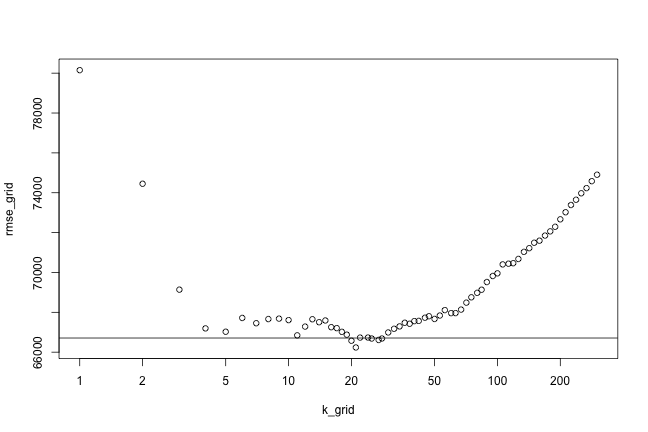

```r
plot(k_grid, rmse_grid, log='x')
abline(h=rmse(ytest, yhat_test2)) # linear model benchmark
```

### Back to your "favorite" linear model

- Return to your “hand-built” model for price, which might have included transformations, newly defined variables, etc.
- See if you can turn that linear model into a better-performing KNN model.
- Note: don't explicitly include interactions or polynomial terms in your KNN model! It is sufficiently adaptable to find them, if they are there.

### Feature engineering

Feature engineering means applying domain-specific knowledge in order to:

1) extract useful features from raw data, and/or  
2) improve the usefulness of existing features for predicting y.

Better features almost always beat a better model!

- Good feature engineering is absolutely vital to success in ML applications.
- Data scientists who work on ML pipelines spend a huge amount of their time thinking about how to engineer/extract more useful features from data sets.

### Common steps in feature engineering

- Extract numbers from time stamps (e.g. month, day of week, hour of day)
- Encode categorical variables as dummy variables (“one-hot encoding”)
- Apply nonlinear transformations (logs, powers, etc) to existing numerical variables
- Combine existing features to form new, derived features
- Discretize: convert continuous features into categorical/discrete features
- Simplify complex features (E.g. heart-rate trace every second –> max/min/average heart rates for the day)
- Merge existing data with new sources that provide additional features
- etc!

### Example

Let's see an example in `feature_engineer.R`.

### Take-home messages

- Linear models always require a choice of scale. Using no transformation is still a choice!
- Selecting and engineering features/interactions are really important components of building a linear model (and for some nonlinear models we'll see later).
- But selecting features by hand is laborious, and selecting interactions by hand is even worse! Stay tuned for more automated methods :-)